# Incarceration Data Analysis

Miranda Ma

11/20/2020

## Introduction + Summary Information

I am focusing on Asian American and Pacific Islander (aapi) jail incarceration population and population rate. This analysis is based on the incarceration trends dataset provided by Vera Institute of Justice.

From working with the dataset, average value of aapi jail population rate across all the counties in 2018 is 446.9205315, while that of 2008 is 699.8127518. The trend of average value of aapi jail population rate across all the counties from 2008 to 2018 is shown below.

```
## # A tibble: 11 x 2
##     year aapi_jail_pop_rate
##    <int>              <dbl>
##  1  2008               700.
##  2  2009               690.
##  3  2010               770.
##  4  2011               633.
##  5  2012               608.
##  6  2013               632.
##  7  2014               689.
##  8  2015               692.
##  9  2016               580.
## 10  2017               618.
## 11  2018               447.
```

## Trends over time Chart

The trends I chose to explore here is the average jail incarceration rate for aapi across all counties from 2008 to 2018. I wanted to explore this to see the trend of this variable and it has a downward slope over the years.

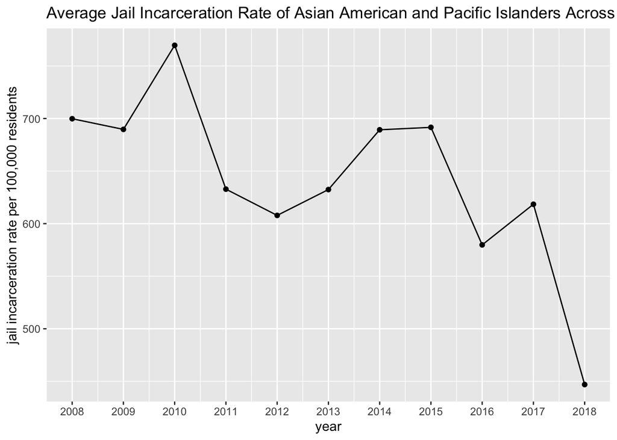

## Variable Comparison Chart

The variables I chose to explore is aapi jail incarceration population and total jail population. From the chart, we can see that there is a somewhat positive relationship between the two variables in that when total jail incarceration population increases, aapi jail incarceration population also increases.

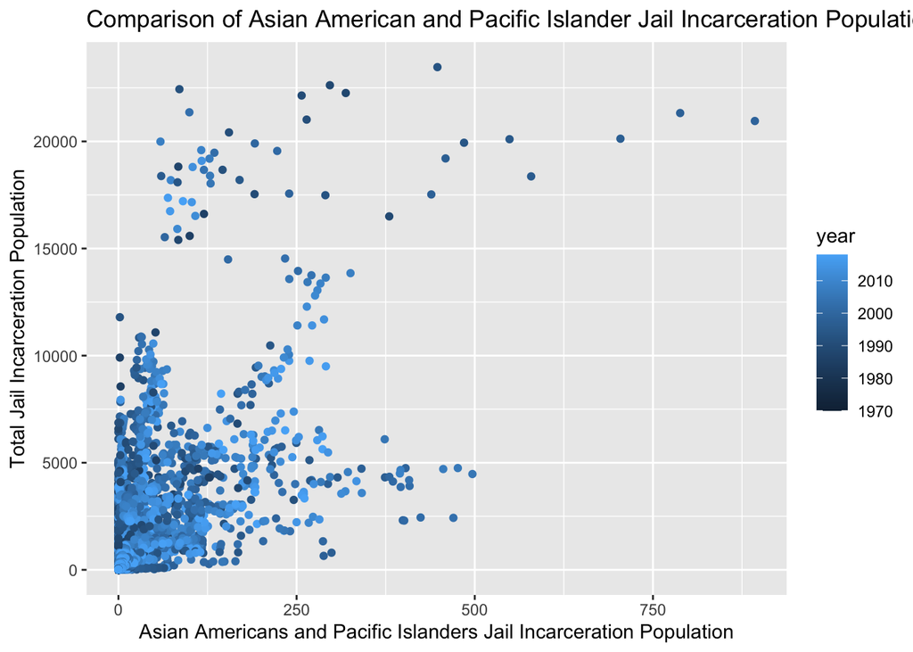

## Map

[figure not shown]